# Web Scrapping MLB Data of San Francisco Giants & Los Angeles Dodgers

## Introduction

I am a huge baseball fan. To be more specific, I am a huge fan of **San Francisco Giants** of the Major League Baseball. What they created as the even year miracle that claimed 3 WS Champisions in 2010, 2012 and 2014 was truely incredible! **Los Angeles Dodgers** is Giants' fierce rival, same relationship as Red Sox against Yankees.

I want to see 2 teams' performance along the seasons and so I create a simple web scraping function to loop through 2 team's batters, starting pitchers, relief pitchers and fielding defensive data along the seasons from MLB Fangraphs. Furthermore, I'll investigate deeply into Giants franchise player performance whom is the leader in terms of team batting and also being one of the top catchers in the league: **Buster Posey**, using Statcast data.

[figure not shown]

## Main Objectives

- *Web scrapping data from MLB Fangraphs ( Using Python Beautiful Soup 4 Package )*
- *Visualize time series data among multiple seasons for comparison to further explore which team is the best as a whole.*
- *Explore the Statcast data of Giants franchise players **Buster Posey**.*

## Function explanation

The function header requires only one variable to input, namely which year of season data you want to extract from the web. The time frame ranging from 1900 til 2018 season and the default is setted to be 2018. The function scraps through the batters overall data, starting pitchers data, relief pitchers data and the fielding defensive data on Fangraphs website.

The 4 types of data are then stored and returned as a list of object. Using index allows us to access each type of data with index 0 being batters data, 1 being starting pitchers, 2 being relief pitchers and 3 being defensive data.

```python
from IPython.display import HTML

HTML('''<script>
code_show=true;
function code_toggle() {
 if (code_show){
 $('div.input').hide();
 } else {
 $('div.input').show();
 }
 code_show = !code_show
}
$( document ).ready(code_toggle);
</script>
<form action="javascript:code_toggle()"><input type="submit" value="Click here to toggle on/off the code."></form>''')
```

```python
# Define a function that can scrap through San Francisco Giants' yearly records of Batters,
# Starting Pitchers, Relief Pitchers and their Fielding records from MLB FanGraph Website
# Default year setting as 2018


def giants_year(year=2018):

    # Import Beautiful Soup 4.0 Packages for Web Scrapping

    import bs4
    from urllib.request import urlopen as uReq
    from bs4 import BeautifulSoup as soup

    # Import Pandas
    import pandas as pd

    giants = 'https://www.fangraphs.com/teams/giants/stats?season='+str(year)

    uClientGiants = uReq(giants)
    html_giants = uClientGiants.read()
    uClientGiants.close()
    soup_giants = soup(html_giants, "html.parser")


    # Find all tables data, batters, starting pitchers, relief pitchers, and fielding records

    teamG = soup_giants.findAll("table", {"class":"tablesort"})

    battersG = teamG[0]
    spG = teamG[1]
    rpG = teamG[2]
    defG =teamG[3]

    # Define Batter Performance column name

    batters_col=[]

    for index in range(len(battersG.thead.tr.findAll('th'))):
        batters_col.append(battersG.thead.tr.findAll('th')[index].text)


    # Define "batter_rec" as a 2*2 list as the table stored batters' performance records.
    # Define "batters_rec" as a 1-dimension list which is each player's records so far in 2018.

    batters_rec = []
    batters_row = []

    # Define a variable "row" that tracks whether "batters_row" have already filled the entire row data
    # and need to change to the next row.

    row = 0

    for index in range(len(battersG.findAll('td'))):

            # loop through the entire webpage and stored the batter's records first into "batters_row"
            # using "row" to check whether "batters_row" reach the maximum stored amounts, 19 columns.
            # Then stored the entire "batters_row" list into "batters_rec" as each row's data. Intialize
            # "batters_row" as an empty list and stored the data again until next time reach the maximum point.

            if row != int(index/len(battersG.thead.tr.findAll('th'))):

                batters_rec.append(batters_row)
                batters_row = []

            batters_row.append(battersG.findAll('td')[index].text)

            row = int(index/len(battersG.thead.tr.findAll('th')))

    #Append the last row into the list, team total records, since the last row won't execute in the if statment

    batters_rec.append(batters_row)

    # Using Pandas DataFrame method to convert the 2*2 list into dataframe type, stored in "batters" variable

    batters = pd.DataFrame(batters_rec)
    batters.columns = batters_col

    season = [year]*len(batters.index)
    batters['Season'] = season


    # Define Starting Pitcher Performance column name

    sp_col = []

    for index in range(len(spG.thead.tr.findAll('th'))):
        sp_col.append(spG.thead.tr.findAll('th')[index].text)


    # Same process as mentioned in retrieved and stored the batters' performance records.

    sp_rec = []
    sp_row = []

    row = 0

    for index in range(len(spG.findAll('td'))):

            if row != int(index/len(spG.thead.tr.findAll('th'))):

                sp_rec.append(sp_row)
                sp_row = []

            sp_row.append(spG.findAll('td')[index].text)

            row = int(index/len(spG.thead.tr.findAll('th')))

    sp_rec.append(sp_row)

    SP = pd.DataFrame(sp_rec)
    SP.columns = sp_col

    season = [year]*len(SP.index)
    SP['Season'] = season

    # Define Relief Pitcher Performance column name

    rp_col = []

    for index in range(len(rpG.thead.tr.findAll('th'))):
        rp_col.append(rpG.thead.tr.findAll('th')[index].text)

    # Retrieved and stored relief pitchers' data
    rp_rec = []
    rp_row = []

    row = 0

    for index in range(len(rpG.findAll('td'))):


            if row != int(index/len(rpG.thead.tr.findAll('th'))):

                rp_rec.append(rp_row)
                rp_row = []

            rp_row.append(rpG.findAll('td')[index].text)

            row = int(index/len(rpG.thead.tr.findAll('th')))


    rp_rec.append(rp_row)

    RP = pd.DataFrame(rp_rec)
    RP.columns = rp_col

    season = [year]*len(RP.index)
    RP['Season'] = season


    # Define Fielding Performance column name

    def_col = []

    for index in range(len(defG.thead.tr.findAll('th'))):
        def_col.append(defG.thead.tr.findAll('th')[index].text)

    # Retrieved and stored relief pitchers' data
    def_rec = []
    def_row = []

    row = 0

    for index in range(len(defG.findAll('td'))):


            if row != int(index/len(defG.thead.tr.findAll('th'))):

                def_rec.append(def_row)
                def_row = []

            def_row.append(defG.findAll('td')[index].text)

            row = int(index/len(defG.thead.tr.findAll('th')))


    def_rec.append(def_row)

    field = pd.DataFrame(def_rec)
    field.columns = def_col

    season = [year]*len(field.index)
    field['Season'] = season

    giants_record = [batters,SP,RP,field]

    return giants_record
```

```python
# Define a function that can scrap through Los Angeles Dodgers yearly records of Batters,
# Starting Pitchers, Relief Pitchers and their Fielding records from MLB FanGraph Website
# Default year setting as 2018

def dodgers_year(year=2018):

    # Import Beautiful Soup 4 Packages for Web Scrapping

    import bs4
    from urllib.request import urlopen as uReq
    from bs4 import BeautifulSoup as soup

    # Import Pandas
    import pandas as pd


    dodgers = 'https://www.fangraphs.com/teams/dodgers/stats?season='+str(year)

    uClientDodgers = uReq(dodgers)
    html_dodgers = uClientDodgers.read()
    uClientDodgers.close()
    soup_dodgers = soup(html_dodgers, "html.parser")


    # Find all tables data, batters, starting pitchers, relief pitchers, and fielding records

    teamD = soup_dodgers.findAll("table", {"class":"tablesort"})

    battersD = teamD[0]
    spD = teamD[1]
    rpD = teamD[2]
    defD =teamD[3]

    # Define Batter Performance column name

    batters_col=[]

    for index in range(len(battersD.thead.tr.findAll('th'))):
        batters_col.append(battersD.thead.tr.findAll('th')[index].text)


    # Define "batter_rec" as a 2*2 list as the table stored batters' performance records.
    # Define "batters_rec" as a 1-dimension list which is each player's records so far in 2018.

    batters_rec = []
    batters_row = []

    # Define a variable "row" that tracks whether "batters_row" have already filled the entire row data
    # and need to change to the next row.

    row = 0

    for index in range(len(battersD.findAll('td'))):

            # loop through the entire webpage and stored the batter's records first into "batters_row"
            # using "row" to check whether "batters_row" reach the maximum stored amounts, 19 columns.
            # Then stored the entire "batters_row" list into "batters_rec" as each row's data. Intialize
            # "batters_row" as an empty list and stored the data again until next time reach the maximum point.

            if row != int(index/len(battersD.thead.tr.findAll('th'))):

                batters_rec.append(batters_row)
                batters_row = []

            batters_row.append(battersD.findAll('td')[index].text)

            row = int(index/len(battersD.thead.tr.findAll('th')))

    # Append the last row into the list, team total records, since the last row won't execute in the if statment

    batters_rec.append(batters_row)

    # Using Pandas DataFrame method to convert the 2*2 list into dataframe type, stored in "batters" variable

    batters = pd.DataFrame(batters_rec)
    batters.columns = batters_col

    season = [year]*len(batters.index)
    batters['Season'] = season


    # Define Starting Pitcher Performance column name

    sp_col = []

    for index in range(len(spD.thead.tr.findAll('th'))):
        sp_col.append(spD.thead.tr.findAll('th')[index].text)


    # Same process as mentioned in retrieved and stored the batters' performance records.

    sp_rec = []
    sp_row = []

    row = 0

    for index in range(len(spD.findAll('td'))):

            if row != int(index/len(spD.thead.tr.findAll('th'))):

                sp_rec.append(sp_row)
                sp_row = []

            sp_row.append(spD.findAll('td')[index].text)

            row = int(index/len(spD.thead.tr.findAll('th')))

    sp_rec.append(sp_row)

    SP = pd.DataFrame(sp_rec)
    SP.columns = sp_col

    season = [year]*len(SP.index)
    SP['Season'] = season

    # Define Relief Pitcher Performance column name

    rp_col = []

    for index in range(len(rpD.thead.tr.findAll('th'))):
        rp_col.append(rpD.thead.tr.findAll('th')[index].text)

    # Retrieved and stored relief pitchers' data
    rp_rec = []
    rp_row = []

    row = 0

    for index in range(len(rpD.findAll('td'))):


            if row != int(index/len(rpD.thead.tr.findAll('th'))):

                rp_rec.append(rp_row)
                rp_row = []

            rp_row.append(rpD.findAll('td')[index].text)

            row = int(index/len(rpD.thead.tr.findAll('th')))

    rp_rec.append(rp_row)

    RP = pd.DataFrame(rp_rec)
    RP.columns = rp_col

    season = [year]*len(RP.index)
    RP['Season'] = season


    # Define Fielding Performance column name

    def_col = []

    for index in range(len(defD.thead.tr.findAll('th'))):
        def_col.append(defD.thead.tr.findAll('th')[index].text)

    # Retrieved and stored relief pitchers' data
    def_rec = []
    def_row = []

    row = 0

    for index in range(len(defD.findAll('td'))):


            if row != int(index/len(defD.thead.tr.findAll('th'))):

                def_rec.append(def_row)
                def_row = []

            def_row.append(defD.findAll('td')[index].text)

            row = int(index/len(defD.thead.tr.findAll('th')))

    def_rec.append(def_row)

    field = pd.DataFrame(def_rec)
    field.columns = def_col

    season = [year]*len(field.index)
    field['Season'] = season

    dodgers_record = [batters,SP,RP,field]

    return dodgers_record
```

## Team Stats Comparison

The seasons chosen to compare ranging from 2000 til present, 2018, however, you can pick any year in the range of 1900 - 2018 to generate any season data you want. What I did here is basically loop through each season year and concatenate the "Team Total" data together for both teams. Later, using basic time series line plot to get a clearer understanding of which team is better in terms of batting, pitching and defensive stats.

Note that for both staring and relief pitching data, **GB%**, **HR/FB** and **xFIP** records were missed for 2000 and 2001 seasons, so I eliminate 2000 and 2001 data for pitching comparison.

> **GB%** : Ground Ball Percentage.

> **HR/FB** : Ratio of homeruns suffering per fastball pitch.

> **xFIP** : Expected Fielding Independent Pitching

```python
import pandas as pd

yr = 2000

giants_batters = []

while yr <= 2018:

    giants_batters.append(giants_year(yr)[0].loc[giants_year(yr)[0]['Name'] == 'Team Total'])
    yr += 1
    battersG_2010_2018 = pd.concat(giants_batters)

yr = 2000

dodgers_batters = []

while yr <= 2018:

    dodgers_batters.append(dodgers_year(yr)[0].loc[dodgers_year(yr)[0]['Name'] == 'Team Total'])
    yr += 1
    battersD_2010_2018 = pd.concat(dodgers_batters)
```

```python
import pandas as pd

yr = 2000

giants_sp = []

while yr <= 2018:

    giants_sp.append(giants_year(yr)[1].loc[giants_year(yr)[1]['Name'] == 'Team Total'])
    yr += 1
    spG_2010_2018 = pd.concat(giants_sp)

yr = 2000

dodgers_sp = []

while yr <= 2018:

    dodgers_sp.append(dodgers_year(yr)[1].loc[dodgers_year(yr)[1]['Name'] == 'Team Total'])
    yr += 1
    spD_2010_2018 = pd.concat(dodgers_sp)
```

```python
import pandas as pd

yr = 2000

giants_rp = []

while yr <= 2018:

    giants_rp.append(giants_year(yr)[2].loc[giants_year(yr)[2]['Name'] == 'Team Total'])
    yr += 1
    rpG_2010_2018 = pd.concat(giants_rp)

yr = 2000

dodgers_rp = []

while yr <= 2018:

    dodgers_rp.append(dodgers_year(yr)[2].loc[dodgers_year(yr)[2]['Name'] == 'Team Total'])
    yr += 1
    rpD_2010_2018 = pd.concat(dodgers_rp)
```

```python
import pandas as pd

yr = 2000

giants_field = []

while yr <= 2018:

    giants_field.append(giants_year(yr)[3].loc[giants_year(yr)[3]['Name'] == 'Team Total'])
    yr += 1
    fieldG_2010_2018 = pd.concat(giants_field)

yr = 2000

dodgers_field = []

while yr <= 2018:

    dodgers_field.append(dodgers_year(yr)[3].loc[dodgers_year(yr)[3]['Name'] == 'Team Total'])
    yr += 1
    fieldD_2010_2018 = pd.concat(dodgers_field)
```

```python
import os
os.chdir('C:\\Users\\user\\Desktop\\mlb')
%pwd

battersG_2010_2018.to_csv('battersG_2010_2018.csv')
battersD_2010_2018.to_csv('battersD_2010_2018.csv')

spG_2010_2018.to_csv('spG_2010_2018.csv')
spD_2010_2018.to_csv('spD_2010_2018.csv')

rpG_2010_2018.to_csv('rpG_2010_2018.csv')
rpD_2010_2018.to_csv('rpD_2010_2018.csv')

fieldG_2010_2018.to_csv('fieldG_2010_2018.csv')
fieldD_2010_2018.to_csv('fieldD_2010_2018.csv')
```

```python
import os
os.chdir('C:\\Users\\user\\Desktop\\mlb')
%pwd

#Reading data from local directory

import pandas as pd

starting_pitchersG = pd.read_csv('spG_2010_2018.csv', index_col = 0)
starting_pitchersD = pd.read_csv('spD_2010_2018.csv', index_col = 0)

relief_pitchersG = pd.read_csv('rpG_2010_2018.csv', index_col = 0)
relief_pitchersD = pd.read_csv('rpD_2010_2018.csv', index_col = 0)

fieldingG = pd.read_csv('fieldG_2010_2018.csv', index_col = 0)
fieldingD = pd.read_csv('fieldD_2010_2018.csv', index_col = 0)

battersG = pd.read_csv('battersG_2010_2018.csv', index_col = 0)
battersD = pd.read_csv('battersD_2010_2018.csv', index_col = 0)
```

```python
#Change datatype of "K%" & "BB%" from strings to float dtype in batting data

battersG['BB%'] = battersG['BB%'].str[:-1].astype(float)*0.01
battersG['K%'] = battersG['K%'].str[:-1].astype(float)*0.01

battersD['BB%'] = battersD['BB%'].str[:-1].astype(float)*0.01
battersD['K%'] = battersD['K%'].str[:-1].astype(float)*0.01

#Include OPS (OPB + SLG) as new column in both teams' data

battersG['OPS'] = battersG['OBP']+battersG['SLG']
battersD['OPS'] = battersD['OBP']+battersD['SLG']

#Include BB (BB% * PA) as new column in both teams' data

battersG['BB'] = battersG['BB%']*battersG['PA']
battersD['BB'] = battersD['BB%']*battersD['PA']


# Define a simple function to round off Base on Balls floating data to integer

def BB(data):
    if(data % 1 >= 0.5):
        data = int(data)+1
    else:
        data = int(data)
    return data

# Apply the function BB() to the "BB" column

battersG['BB'] = battersG['BB'].apply(BB)
battersD['BB'] = battersD['BB'].apply(BB)

# Include "HR%" stands for homers generated per plate appearance, using "HR" data divided by "PA"

battersG['HR%'] = battersG['HR']/battersG['PA']
battersD['HR%'] = battersD['HR']/battersD['PA']
```

```python
#Correct datatypes of "K%", "BB%", "GB%", "LOB%" and "HR/FB" for both starting & relief pitching data

relief_pitchersG['BB%']   = relief_pitchersG['BB%'].str[:-1].astype(float)*0.01
relief_pitchersG['K%']    = relief_pitchersG['K%'].str[:-1].astype(float)*0.01
relief_pitchersG['GB%']   = relief_pitchersG['GB%'].str[:-1].astype(float)*0.01
relief_pitchersG['LOB%']  = relief_pitchersG['LOB%'].str[:-1].astype(float)*0.01
relief_pitchersG['HR/FB'] = relief_pitchersG['HR/FB'].str[:-1].astype(float)*0.01
```

```python
relief_pitchersD['BB%']   = relief_pitchersD['BB%'].str[:-1].astype(float)*0.01
relief_pitchersD['K%']    = relief_pitchersD['K%'].str[:-1].astype(float)*0.01
relief_pitchersD['GB%']   = relief_pitchersD['GB%'].str[:-1].astype(float)*0.01
relief_pitchersD['HR/FB'] = relief_pitchersD['HR/FB'].str[:-1].astype(float)*0.01
```

```python
starting_pitchersG['BB%'] = starting_pitchersG['BB%'].str[:-1].astype(float)*0.01
starting_pitchersG['K%'] = starting_pitchersG['K%'].str[:-1].astype(float)*0.01
starting_pitchersG['GB%'] = starting_pitchersG['GB%'].str[:-1].astype(float)*0.01
starting_pitchersG['LOB%'] = starting_pitchersG['LOB%'].str[:-1].astype(float)*0.01
starting_pitchersG['HR/FB'] = starting_pitchersG['HR/FB'].str[:-1].astype(float)*0.01
```

```python
starting_pitchersD['BB%'] = starting_pitchersD['BB%'].str[:-1].astype(float)*0.01
starting_pitchersD['K%'] = starting_pitchersD['K%'].str[:-1].astype(float)*0.01
starting_pitchersD['GB%'] = starting_pitchersD['GB%'].str[:-1].astype(float)*0.01
starting_pitchersD['HR/FB'] = starting_pitchersD['HR/FB'].str[:-1].astype(float)*0.01
```

```python
#Reindex the data set by the seasons, drop 2000 and 2001 records which contains missing values for SP & RP data

battersG = battersG.set_index(battersG.Season).sort_index()
battersD = battersD.set_index(battersD.Season).sort_index()

starting_pitchersG = starting_pitchersG.set_index(starting_pitchersG.Season).sort_index()
starting_pitchersD = starting_pitchersD.set_index(starting_pitchersD.Season).sort_index()

relief_pitchersG = relief_pitchersG.set_index(relief_pitchersG.Season).sort_index()
relief_pitchersD = relief_pitchersD.set_index(relief_pitchersD.Season).sort_index()

starting_pitchersG = starting_pitchersG.loc['2002':'2018']
starting_pitchersD = starting_pitchersD.loc['2002':'2018']

relief_pitchersG = relief_pitchersG.loc['2002':'2018']
relief_pitchersD = relief_pitchersD.loc['2002':'2018']
```

### Team Batting Data (Top: SF Giants / Bottom: LA Dodgers)

```python
battersG['Name'] = "Giants"
battersG.head()
```

| Season | Name | Age | G | PA | HR | SB | BB% | K% | ISO | BABIP | ... | wOBA | wRC+ | BsR | Off | Def | WAR | Season | OPS | BB | HR% |
| --- | --- | --- | --- | --- | --- | --- | --- | --- | --- | --- | --- | --- | --- | --- | --- | --- | --- | --- | --- | --- | --- |
| 2000 | Giants | 29 | 2123 | 6418 | 226 | 79 | 0.110 | 0.161 | 0.194 | 0.303 | ... | 0.359 | 112 | -1.3 | 103.7 | 53.7 | 34.7 | 2000 | 0.834 | 706 | 0.035213 |
| 2001 | Giants | 30 | 2231 | 6408 | 235 | 57 | 0.098 | 0.170 | 0.194 | 0.290 | ... | 0.341 | 108 | -7.2 | 60.2 | 46.3 | 30.9 | 2001 | 0.802 | 628 | 0.036673 |
| 2002 | Giants | 30 | 2263 | 6304 | 198 | 74 | 0.098 | 0.152 | 0.175 | 0.289 | ... | 0.338 | 109 | 2.8 | 73.5 | 72.1 | 35.1 | 2002 | 0.786 | 618 | 0.031409 |
| 2003 | Giants | 29 | 2272 | 6204 | 180 | 53 | 0.096 | 0.158 | 0.161 | 0.291 | ... | 0.330 | 100 | -8.3 | -11.7 | 94.8 | 28.2 | 2003 | 0.763 | 596 | 0.029014 |
| 2004 | Giants | 29 | 2405 | 6466 | 183 | 43 | 0.109 | 0.135 | 0.168 | 0.290 | ... | 0.340 | 105 | -6.0 | 35.7 | 28.4 | 27.5 | 2004 | 0.795 | 705 | 0.028302 |

5 rows × 23 columns

```python
battersD['Name'] = "Dodgers"
battersD.head()
```

| Season | Name | Age | G | PA | HR | SB | BB% | K% | ISO | BABIP | ... | wOBA | wRC+ | BsR | Off | Def | WAR | Season | OPS | BB | HR% |
| --- | --- | --- | --- | --- | --- | --- | --- | --- | --- | --- | --- | --- | --- | --- | --- | --- | --- | --- | --- | --- | --- |
| 2000 | Dodgers | 30 | 2057 | 6312 | 211 | 95 | 0.106 | 0.172 | 0.174 | 0.283 | ... | 0.337 | 99 | 0.5 | -4.5 | 46.3 | 23.7 | 2000 | 0.772 | 669 | 0.033428 |
| 2001 | Dodgers | 31 | 2084 | 6169 | 206 | 89 | 0.084 | 0.172 | 0.170 | 0.279 | ... | 0.322 | 97 | -0.7 | -23.8 | 9.0 | 18.2 | 2001 | 0.748 | 518 | 0.033393 |
| 2002 | Dodgers | 30 | 2302 | 6147 | 155 | 96 | 0.070 | 0.153 | 0.146 | 0.291 | ... | 0.317 | 96 | -3.5 | -36.3 | 73.4 | 23.7 | 2002 | 0.729 | 430 | 0.025216 |
| 2003 | Dodgers | 30 | 2292 | 6036 | 124 | 80 | 0.067 | 0.163 | 0.125 | 0.275 | ... | 0.294 | 78 | -10.2 | -178.7 | 84.4 | 10.2 | 2003 | 0.671 | 404 | 0.020543 |
| 2004 | Dodgers | 30 | 2357 | 6244 | 203 | 102 | 0.086 | 0.175 | 0.161 | 0.291 | ... | 0.327 | 97 | 1.7 | -19.9 | 96.9 | 28.0 | 2004 | 0.755 | 537 | 0.032511 |

5 rows × 23 columns

### SF Giants Team Pitching Data Table (Top: SP / Bottom: RP)

```python
starting_pitchersG['Name'] = "Giants"
starting_pitchersG.head()
```

| Season | Name | Age | G | GS | IP | K% | BB% | HR/9 | BABIP | LOB% | GB% | HR/FB | ERA | FIP | xFIP | WAR | Season |
| --- | --- | --- | --- | --- | --- | --- | --- | --- | --- | --- | --- | --- | --- | --- | --- | --- | --- |
| 2002 | Giants | 27 | 162 | 162 | 1004.1 | 0.154 | 0.086 | 0.83 | 0.283 | 0.729 | 0.419 | 0.083 | 3.83 | 4.01 | 4.35 | 12.5 | 2002 |
| 2003 | Giants | 27 | 161 | 161 | 949.2 | 0.159 | 0.088 | 0.94 | 0.277 | 0.743 | 0.432 | 0.098 | 3.86 | 4.25 | 4.45 | 11.6 | 2003 |
| 2004 | Giants | 28 | 162 | 162 | 981.2 | 0.161 | 0.080 | 0.93 | 0.282 | 0.697 | 0.453 | 0.095 | 4.18 | 4.11 | 4.32 | 13.9 | 2004 |
| 2005 | Giants | 28 | 162 | 162 | 940.0 | 0.156 | 0.093 | 1.04 | 0.288 | 0.716 | 0.410 | 0.096 | 4.52 | 4.47 | 4.62 | 9.5 | 2005 |
| 2006 | Giants | 29 | 161 | 161 | 982.2 | 0.156 | 0.089 | 0.99 | 0.282 | 0.688 | 0.424 | 0.091 | 4.58 | 4.53 | 4.81 | 11.7 | 2006 |

```python
relief_pitchersG['Name'] = "Giants"
relief_pitchersG.head()
```

| Season | Name | Age | G | GS | IP | K% | BB% | HR/9 | BABIP | LOB% | GB% | HR/FB | ERA | FIP | xFIP | WAR | Season |
| --- | --- | --- | --- | --- | --- | --- | --- | --- | --- | --- | --- | --- | --- | --- | --- | --- | --- |
| 2002 | Giants | 29 | 417 | 0 | 433.0 | 0.188 | 0.087 | 0.48 | 0.277 | 0.766 | 0.432 | 0.050 | 2.91 | 3.31 | 4.10 | 5.6 | 2002 |
| 2003 | Giants | 29 | 461 | 0 | 487.2 | 0.177 | 0.093 | 0.68 | 0.280 | 0.745 | 0.440 | 0.073 | 3.47 | 3.79 | 4.32 | 4.2 | 2003 |
| 2004 | Giants | 29 | 521 | 0 | 475.1 | 0.162 | 0.100 | 1.14 | 0.308 | 0.721 | 0.440 | 0.110 | 4.68 | 4.72 | 4.71 | -1.2 | 2004 |
| 2005 | Giants | 30 | 511 | 0 | 504.1 | 0.153 | 0.096 | 0.75 | 0.289 | 0.717 | 0.445 | 0.078 | 4.03 | 4.12 | 4.52 | 2.2 | 2005 |
| 2006 | Giants | 29 | 438 | 0 | 447.0 | 0.166 | 0.104 | 0.91 | 0.297 | 0.697 | 0.407 | 0.085 | 4.77 | 4.50 | 4.86 | 1.3 | 2006 |

### LA Dodgers Team Pitching Data Table (Top: SP / Bottom: RP)

```python
starting_pitchersD['Name'] = "Dodgers"
starting_pitchersD.head()
```

| Season | Name | Age | G | GS | IP | K% | BB% | HR/9 | BABIP | LOB% | GB% | HR/FB | ERA | FIP | xFIP | WAR | Season |
| --- | --- | --- | --- | --- | --- | --- | --- | --- | --- | --- | --- | --- | --- | --- | --- | --- | --- |
| 2002 | Dodgers | 30 | 162 | 162 | 986.0 | 0.179 | 0.092 | 1.02 | 0.270 | 75.1% | 0.417 | 0.108 | 3.74 | 4.18 | 4.16 | 12.5 | 2002 |
| 2003 | Dodgers | 31 | 162 | 162 | 985.0 | 0.199 | 0.091 | 0.89 | 0.287 | 75.8% | 0.479 | 0.113 | 3.49 | 3.86 | 3.85 | 17.5 | 2003 |
| 2004 | Dodgers | 29 | 162 | 162 | 935.1 | 0.150 | 0.079 | 1.30 | 0.274 | 71.7% | 0.399 | 0.116 | 4.53 | 4.75 | 4.63 | 9.5 | 2004 |
| 2005 | Dodgers | 29 | 162 | 162 | 955.1 | 0.154 | 0.065 | 1.24 | 0.281 | 70.5% | 0.477 | 0.130 | 4.36 | 4.44 | 4.11 | 10.3 | 2005 |
| 2006 | Dodgers | 30 | 162 | 162 | 922.2 | 0.147 | 0.072 | 0.90 | 0.305 | 70.3% | 0.501 | 0.096 | 4.29 | 4.19 | 4.36 | 14.5 | 2006 |

```python
relief_pitchersD['Name'] = "Dodgers"
relief_pitchersD.head()
```

| Season | Name | Age | G | GS | IP | K% | BB% | HR/9 | BABIP | LOB% | GB% | HR/FB | ERA | FIP | xFIP | WAR | Season |
| --- | --- | --- | --- | --- | --- | --- | --- | --- | --- | --- | --- | --- | --- | --- | --- | --- | --- |
| 2002 | Dodgers | 32 | 423 | 0 | 471.2 | 0.195 | 0.087 | 1.01 | 0.271 | 76.3% | 0.440 | 0.106 | 3.59 | 3.98 | 3.99 | 3.9 | 2002 |
| 2003 | Dodgers | 30 | 438 | 0 | 472.2 | 0.251 | 0.080 | 0.57 | 0.264 | 79.9% | 0.483 | 0.086 | 2.46 | 2.93 | 3.18 | 9.6 | 2003 |
| 2004 | Dodgers | 30 | 459 | 0 | 518.0 | 0.215 | 0.096 | 0.75 | 0.288 | 79.5% | 0.444 | 0.085 | 3.06 | 3.66 | 3.98 | 6.7 | 2004 |
| 2005 | Dodgers | 28 | 458 | 0 | 472.0 | 0.184 | 0.101 | 0.95 | 0.293 | 71.4% | 0.422 | 0.100 | 4.42 | 4.30 | 4.39 | 1.0 | 2005 |
| 2006 | Dodgers | 29 | 454 | 0 | 537.2 | 0.209 | 0.089 | 1.00 | 0.298 | 71.7% | 0.433 | 0.099 | 4.12 | 4.04 | 4.17 | 5.2 | 2006 |

## Visualize the data

Comparing the batting performance along the seasons for both teams. Using time series to explore the difference between each season. The metrics chosen to compare are **K%**, **BB%** and **OPS** as a whole to see the gross batting performance in terms of been striked-out percentage, base on balls and On Base Percentage plus Slugging value.

> **K%** (Strikout Percentage) : Percentage of the team batters got strikeouts.

> **BB%** (Base on Balls Percentage) : Percentage of the team batters get on the base on balls.

> **OPS** (On base percentage Plus Slugging) : Literally on base percentage (OBP) + slugging percentage (SLG).

> ( Higher BB% & OPS indicates a better performance of the team comparing to its counterpart. A higher K% doesn't necessarily mean a bad performance, thus would need to investigate other data. )

These are general evaluations of the batters performance, but lack of a more holistic view considering other aspects such as eliminating fielding errors, ball parks factor and so on. To get a more precisive measurment for individual offensive performance we then include another 3 metrics, namely **wOBA**, **WAR** and **wRC+**.

> **wOBA** (Weighted On Base Percentage) : A stats based on linear weights, designed to measure a player's overall offensive contributions per plate appearance. Fixed the OBP undervalued issue caused by OPS.

> **WAR** (Wins Above Replacement) : Developed to sum up a player's total contributions to his team. To put it simply, how many wins added to the team by adding such player to the team roster.

> **wRC+** (Weighted Run Created) : An improved version of Bill James’ Runs Created (RC) statistic, which attempted to quantify a player’s total offensive value and measure it by runs. Adding ball park factors to the original wRC stats. League general average is 100 but do having a slight difference among the seasons.

> ( The higher the 3 statistics are, the better performance the team is comparing to its counterpart. Note that the stats only give a broad concept for comparison, serve as an indicator for relative conclusion.)

Addition info...

The defintion of the metrics are derived from [Fangraphs Sabermetrics Library](https://www.fangraphs.com/library/)

The team data color are picked based on [Team color](http://jim-nielsen.com/teamcolors/), contributed by Jim Nielsen

## Batting Stats Comparison ( K% / BB% / OPS )

As Fangraphs suggests that the **K%** among the league has a rising tendency in recent years. Additionaly, the formula changed from **( Strikeouts / At Bats )** to **( Strikeouts / Plate Appearance )** in 2011. Thus the data here might be a little bias since we include different metrics calculation methods.

### K% & BB%

Considering both **K%** & **BB%**, both teams have a rising tendency on **K%** in the past decade. The **BB%** are a bit stochastic, except for 2016 season, Dodgers basically beated Giants in the past decades and is on a rising trend along the way.

### OPS

Giants' team OPS figures has a down trend in general while Dodgers has a stochastic trend. Likewise, we compare 2 teams performance in the past decade. While Giants outpaced Dodgers in the 2010 and 2012 seasons, 2016 seems like a tie, Dodgers won the rest of the seasons.

**- Note that the league average varies along different eras. A higher record in K% doesn't mean it's certainly the worst, same as having a higher OPS along the seasons, but for comparing 2 teams, the data is sufficient to give us a whole picture of relative team performance.**

### HR / BB

Total BB amounts are pretty easy to obtain by multiplying BB% with PA amounts. Generating additional bar charts to look at both teams' HR and BB production, Giants beated Dodgers on BB stats in 2000-2004, yet lost on HR amounts in 2004. In early years of 2000 to 2004, both teams have a great offensive performance. If we take a look at both K% and BB% stats along the seasons, both teams have a high walk percentage and low strikeout percentage in the early 2000s.

That was pretty common in the league back then, the fierce batting era where we got **Barry Bonds**, **Derek Jeter**, **Ichiro Suzuki**, **Alex Rodríguez**, **Albert Pujols** and other super stars wreaked havoc in every game. When faced all these sluggers, common strategy was to walk the batters intentionally. Plus all these batters not only knew how to generate homers, but also stayed high contact without swinging to balls.

To see a clearer difference between 2 teams, plotting the time series of HR% and BB% down below by using BB and HR amounts divided by PA ( Plate Appearance ). Giants beated Dodgers of both stats in the early 2000s, and fell behind in the recent years.

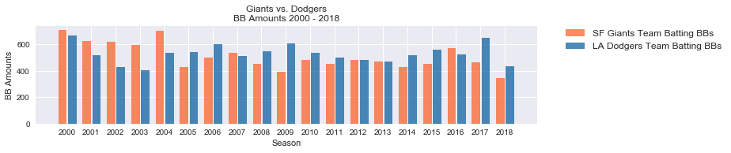

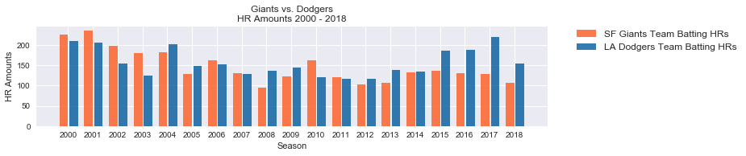

```python
import matplotlib.pyplot as plt
import seaborn as sns

plt.figure(figsize=(25,16))
plt.subplot(6,2,5)
bar_width = 0.35
plt.bar(battersG['Season'], battersG['BB'], bar_width, color = "#FD5A1E", label = 'SF Giants Team Batting BBs', alpha = .7)
plt.bar(battersD['Season']+bar_width+.05, battersD['BB'], bar_width, color ="#005A9C", label = 'LA Dodgers Team Batting BBs', alpha = .7)
plt.title('Giants vs. Dodgers\nBB Amounts 2000 - 2018')
plt.xlabel('Season')
plt.xticks(battersD['Season']+bar_width/2, battersG.index)
plt.ylabel('BB Amounts')
plt.legend(bbox_to_anchor=(1.05, 1), loc=2, borderaxespad=0.,prop={'size': 'medium'})
plt.show()


plt.figure(figsize=(25,16))
plt.subplot(6,2,6)
bar_width = 0.35
plt.bar(battersG['Season'], battersG['HR'], bar_width, color = "#FD5A1E", label = 'SF Giants Team Batting HRs', alpha = .8)
plt.bar(battersD['Season']+bar_width+.05, battersD['HR'], bar_width, color ="#005A9C", label = 'LA Dodgers Team Batting HRs', alpha = .8)
plt.title('Giants vs. Dodgers\nHR Amounts 2000 - 2018')
plt.xlabel('Season')
plt.xticks(battersD['Season']+bar_width/2, battersG.index)
plt.ylabel('HR Amounts')
plt.legend(bbox_to_anchor=(1.05, 1), loc=2, borderaxespad=0.,prop={'size': 'medium'})
plt.show()
```

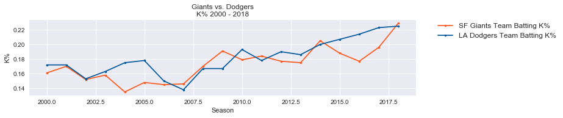

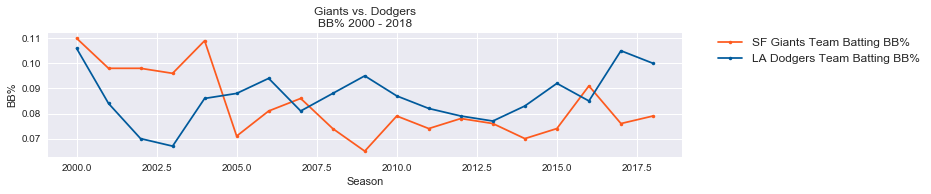

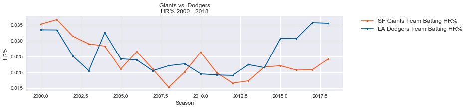

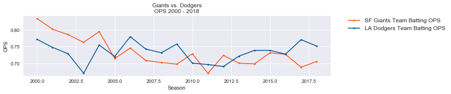

```python
import matplotlib.pyplot as plt
import seaborn as sns

plt.clf()
plt.figure(figsize=(25,16))
plt.subplot(6,2,1)
plt.plot(battersG['Season'], battersG['K%'], color = "#FD5A1E",marker='.', label = 'SF Giants Team Batting K%')
plt.plot(battersD['Season'], battersD['K%'], color ="#005A9C", marker='.', label = 'LA Dodgers Team Batting K%')
plt.title('Giants vs. Dodgers\nK% 2000 - 2018')
plt.xlabel('Season')
plt.ylabel('K%')
plt.legend(bbox_to_anchor=(1.05, 1), loc=2, borderaxespad=0.,prop={'size': 'medium'})
plt.show()

plt.figure(figsize=(25,16))
plt.subplot(6,2,2)
plt.plot(battersG['Season'], battersG['BB%'], color = "#FD5A1E", marker='.', label = 'SF Giants Team Batting BB%')
plt.plot(battersD['Season'], battersD['BB%'], color ="#005A9C", marker='.', label = 'LA Dodgers Team Batting BB%')
plt.title('Giants vs. Dodgers\nBB% 2000 - 2018')
plt.xlabel('Season')
plt.ylabel('BB%')
plt.legend(bbox_to_anchor=(1.05, 1), loc=2, borderaxespad=0.,prop={'size': 'medium'})
plt.show()

plt.figure(figsize=(25,16))
plt.subplot(5,2,4)
plt.plot(battersG['Season'], battersG['HR%'], color = "#FD5A1E", marker='.', label = 'SF Giants Team Batting HR%')
plt.plot(battersD['Season'], battersD['HR%'], color ="#005A9C", marker='.', label = 'LA Dodgers Team Batting HR%')
plt.title('Giants vs. Dodgers\nHR% 2000 - 2018')
plt.xlabel('Season')
plt.ylabel('HR%')
plt.legend(bbox_to_anchor=(1.05, 1), loc=2, borderaxespad=0.,prop={'size': 'medium'})
plt.show()

plt.figure(figsize=(25,16))
plt.subplot(6,2,3)
plt.plot(battersG['Season'], battersG['OPS'], color = "#FD5A1E", marker='.', label = 'SF Giants Team Batting OPS')
plt.plot(battersD['Season'], battersD['OPS'], color ="#005A9C", marker='.', label = 'LA Dodgers Team Batting OPS')
plt.title('Giants vs. Dodgers\nOPS 2000 - 2018')
plt.xlabel('Season')
plt.ylabel('OPS')
plt.legend(bbox_to_anchor=(1.05, 1), loc=2, borderaxespad=0.,prop={'size': 'medium'})
plt.show()
```

## ( wOBA / WAR / wRC+ )

The 3 advanced stats developed to cover uncertainty factors such as different ball parks influence, team defensive performance..etc. For either teams, the time series of these 3 stats have a nearly identical trend, same as OPS. Dodgers seems to have a severe offensive drought in 2003 season. Before 2005, Giants had a better offensive performance. whereas Dodgers took the lead among 2005-2009. After that was a stochastic fluctuation, but Giants outpaced its opponent in their even years WS champions of 2010 and 2012. The stats of 2014, however, didn't win as expected.

## Giants Golden Era of Power (2000 - 2004)

[figure not shown]

For the early years among 2000 til 2004, Giants has extreme power outburst based on the overall batting stats. These years are Giants' **Barry Bonds Dynasty**. A super slugger that boosted the power in the Giants arsenal.

His data is such an outlier, during the 5-year time frame, slashed *49, **73**, 46, 45, 45* **Homeruns**, and batted *.306, .328, **.370**, .341, .362* in **AVG** at the same time. The team batting is at their golden era, but only made it to the World Series once in 2002 led by **Felipe Alou**. Nevertheless, they were still a great offensive team back then. After 2005, the team's batting performance had dropped, yet still clutched 3 World Series Champions in 2010, 2012 and 2014.

**Note that 2018 season isn't over when I scrap the data, but Giants seems unlikely to enter the postseason based on their current standings and other team statistics, we'll see how it goes!**

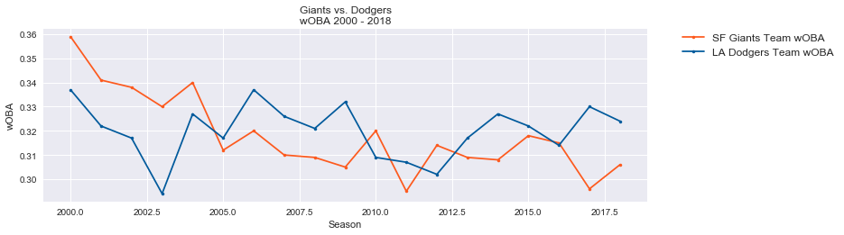

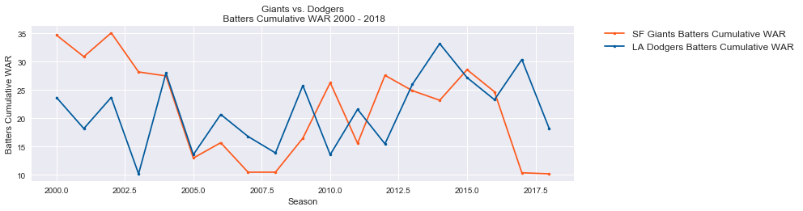

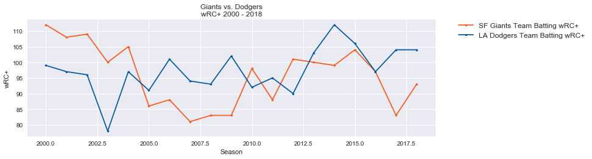

```python
import matplotlib.pyplot as plt
import seaborn as sns

plt.figure(figsize=(12,12))
plt.subplot(3,1,1)
plt.plot(battersG['Season'], battersG['wOBA'], color = "#FD5A1E", marker='.', label = 'SF Giants Team wOBA')
plt.plot(battersD['Season'], battersD['wOBA'], color ="#005A9C", marker='.', label = 'LA Dodgers Team wOBA')
plt.title('Giants vs. Dodgers\nwOBA 2000 - 2018')
plt.xlabel('Season')
plt.ylabel('wOBA')
plt.legend(bbox_to_anchor=(1.05, 1), loc=2, borderaxespad=0.,prop={'size': 'medium'})

plt.show()


plt.figure(figsize=(12,12))
plt.subplot(3,1,2)
plt.plot(battersG['Season'], battersG['WAR'], color = "#FD5A1E", marker='.', label = 'SF Giants Batters Cumulative WAR')
plt.plot(battersD['Season'], battersD['WAR'], color ="#005A9C", marker='.', label = 'LA Dodgers Batters Cumulative WAR')
plt.title('Giants vs. Dodgers\n Batters Cumulative WAR 2000 - 2018')
plt.xlabel('Season')
plt.ylabel('Batters Cumulative WAR')
plt.legend(bbox_to_anchor=(1.05, 1), loc=2, borderaxespad=0.,prop={'size': 'medium'})
plt.show()




plt.figure(figsize=(12,12))
plt.subplot(3,1,3)
plt.plot(battersG['Season'], battersG['wRC+'], color = "#FD5A1E", marker='.', label = 'SF Giants Team Batting wRC+')
plt.plot(battersD['Season'], battersD['wRC+'], color ="#005A9C", marker='.', label = 'LA Dodgers Team Batting wRC+')
plt.title('Giants vs. Dodgers\nwRC+ 2000 - 2018')
plt.xlabel('Season')
plt.ylabel('wRC+')
plt.legend(bbox_to_anchor=(1.05, 1), loc=2, borderaxespad=0.,prop={'size': 'medium'})
plt.show()
```

## Pitching Stats Comparison ( xFIP / WAR / ERA )

**xFIP** is much proper to measure individual performance, an improved version of FIP (Field Independent Performance). Other statistics that are put into consideration are **WAR** and **ERA**. The metrics description are stated below.

> **FIP** (Field Independent Performance) : A measurement of a pitcher’s performance that strips out the role of defense, luck, and sequencing, making it a more stable indicator of how a pitcher actually performed over a given period of time. Expected Fielding Independent Pitching **(xFIP)** is a regressed version of FIP.

> **WAR** (Win Above Replacement) : Pitchers cumulative wins above replacement.

> **ERA** (Earned Runs Average) : How many runs a pitchers earned per 9 innings.

> ( For **xFIP** & **ERA**, the lower the stats is, the better the pitchers' performance are. **WAR** in a simple explanation way is that how many wins the overall pitchers contributed to the team, thus, the higher the better. )

## Starting Pitchers

For **xFIP**, Giants had relatively low performance compared to Dodgers as a whole, both teams' xFIP of starting pitchers was relatively higher in the early 2000s compared to recent years. This also justified the fierce batting era of MLB back at the same time as we mentioned earlier. Looking at other 2 statistics, realized that Giants have no advantage on the starting pitchers aspect.

xFIP and WAR can serve as a individual performance, thus even with a lower performance, the pitchers can still be saved by the team defense, luck. However, for the ERA, the starting pitchers in Giants team didn't ease the runs created compared to Dodgers as a whole. They did win in few seasons, but in general, the overall ERA record is on a rising trend.

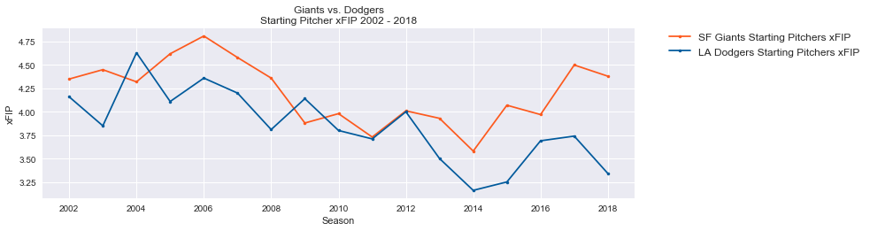

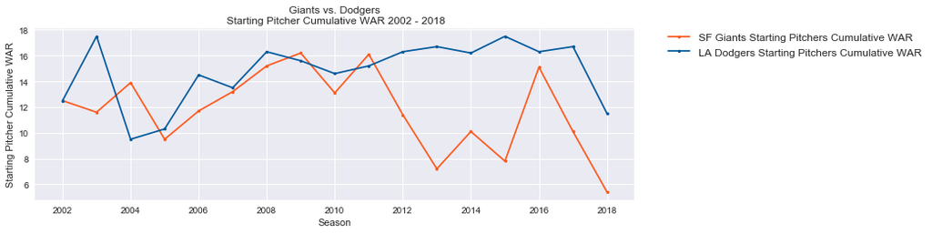

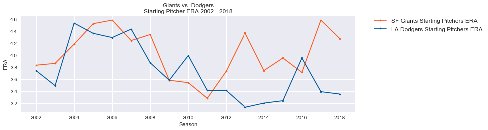

```python
import matplotlib.pyplot as plt
import seaborn as sns

plt.clf()
plt.figure(figsize=(12,12))
plt.subplot(3,1,1)
plt.plot(starting_pitchersG['Season'], starting_pitchersG['xFIP'], color = "#FD5A1E", marker='.', label = 'SF Giants Starting Pitchers xFIP')
plt.plot(starting_pitchersD['Season'], starting_pitchersD['xFIP'], color ="#005A9C", marker='.', label = 'LA Dodgers Starting Pitchers xFIP')
plt.title('Giants vs. Dodgers\nStarting Pitcher xFIP 2002 - 2018')
plt.xlabel('Season')
plt.ylabel('xFIP')
plt.legend(bbox_to_anchor=(1.05, 1), loc=2, borderaxespad=0.,prop={'size': 'medium'})
plt.show()


plt.figure(figsize=(12,12))
plt.subplot(3,1,2)
plt.plot(starting_pitchersG['Season'], starting_pitchersG['WAR'], color = "#FD5A1E", marker='.', label = 'SF Giants Starting Pitchers Cumulative WAR')
plt.plot(starting_pitchersD['Season'], starting_pitchersD['WAR'], color ="#005A9C", marker='.', label = 'LA Dodgers Starting Pitchers Cumulative WAR')
plt.title('Giants vs. Dodgers\n Starting Pitcher Cumulative WAR 2002 - 2018')
plt.xlabel('Season')
plt.ylabel('Starting Pitcher Cumulative WAR')
plt.legend(bbox_to_anchor=(1.05, 1), loc=2, borderaxespad=0.,prop={'size': 'medium'})
plt.show()


plt.figure(figsize=(12,12))
plt.subplot(3,1,3)
plt.plot(starting_pitchersG['Season'], starting_pitchersG['ERA'], color = "#FD5A1E", marker='.', label = 'SF Giants Starting Pitchers ERA')
plt.plot(starting_pitchersD['Season'], starting_pitchersD['ERA'], color ="#005A9C", marker='.', label = 'LA Dodgers Starting Pitchers ERA')
plt.title('Giants vs. Dodgers\nStarting Pitcher ERA 2002 - 2018')
plt.xlabel('Season')
plt.ylabel('ERA')
plt.legend(bbox_to_anchor=(1.05, 1), loc=2, borderaxespad=0.,prop={'size': 'medium'})
plt.show()
```

## Relief Pitchers

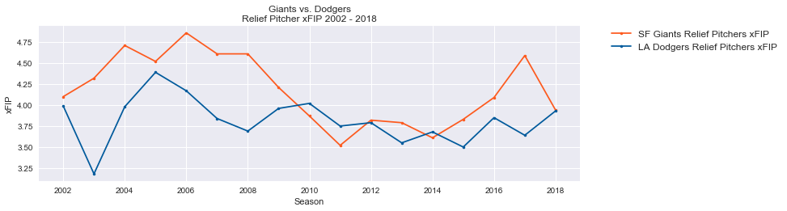

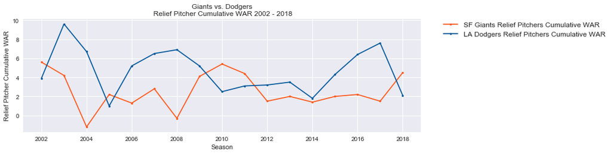

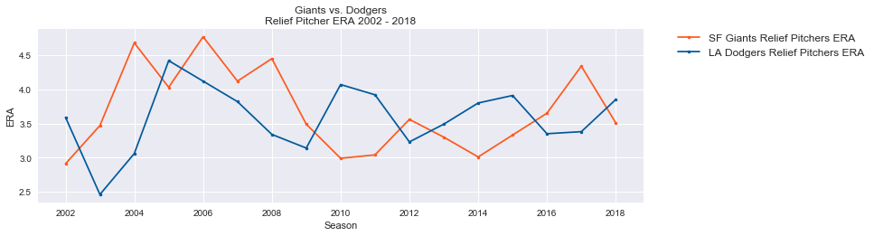

```python
import matplotlib.pyplot as plt
import seaborn as sns

plt.clf()
plt.figure(figsize=(12,12))
plt.subplot(3,1,1)
plt.plot(relief_pitchersG['Season'], relief_pitchersG['xFIP'], color = "#FD5A1E", marker='.', label = 'SF Giants Relief Pitchers xFIP')
plt.plot(relief_pitchersD['Season'], relief_pitchersD['xFIP'], color ="#005A9C", marker='.', label = 'LA Dodgers Relief Pitchers xFIP')
plt.title('Giants vs. Dodgers\nRelief Pitcher xFIP 2002 - 2018')
plt.xlabel('Season')
plt.ylabel('xFIP')
plt.legend(bbox_to_anchor=(1.05, 1), loc=2, borderaxespad=0.,prop={'size': 'medium'})
plt.show()


plt.figure(figsize=(12,12))
plt.subplot(3,1,2)
plt.plot(relief_pitchersG['Season'], relief_pitchersG['WAR'], color = "#FD5A1E", marker='.', label = 'SF Giants Relief Pitchers Cumulative WAR')
plt.plot(relief_pitchersD['Season'], relief_pitchersD['WAR'], color ="#005A9C", marker='.', label = 'LA Dodgers Relief Pitchers Cumulative WAR')
plt.title('Giants vs. Dodgers\n Relief Pitcher Cumulative WAR 2002 - 2018')
plt.xlabel('Season')
plt.ylabel('Relief Pitcher Cumulative WAR')
plt.legend(bbox_to_anchor=(1.05, 1), loc=2, borderaxespad=0.,prop={'size': 'medium'})
plt.show()


plt.figure(figsize=(12,12))
plt.subplot(3,1,3)
plt.plot(relief_pitchersG['Season'], relief_pitchersG['ERA'], color = "#FD5A1E", marker='.', label = 'SF Giants Relief Pitchers ERA')
plt.plot(relief_pitchersD['Season'], relief_pitchersD['ERA'], color ="#005A9C", marker='.', label = 'LA Dodgers Relief Pitchers ERA')
plt.title('Giants vs. Dodgers\nRelief Pitcher ERA 2002 - 2018')
plt.xlabel('Season')
plt.ylabel('ERA')
plt.legend(bbox_to_anchor=(1.05, 1), loc=2, borderaxespad=0.,prop={'size': 'medium'})
plt.show()
```

## A few takeaway

We've seen the batting and pitching comparison for both teams, Giants didn't outbeat Dodgers in terms of overall performance in this century, yet won more champions title than Dodgers, 3-0. The data I scraped is regular season data, once the team entered the postseason, that's another story to tell. In addition, we only compared 2 teams here, in order to see who will win the champion, we need the whole 30 teams data, meaning more statistics and metrics to be included. Giants' 3 WS Champions always contained some specific players to score or defended at the critical timing, striked harder in any desperate situation.

If those who witnessed how Madison Bumgarner single handly got the team out of the jams in 2014 postseason, Tim Lincecum, former 2-time Cy Young award winner who served as one of the iron relievers alongside with Brian Wilson in 2010's victory and offensive line with Pablo Sandoval, Hunter Pence, Brandon Belt, Marco Scutaro as well as Buster Posey helped the team scores, you'll know what I am talking about. There's always someone standed out and defended the team's victory in those postseasons. And last but not least, baseball is such a sports with so much variation, it'll just keep surprising you.

# Statcast Data Exploration

Statcast is a high-speed, high-accuracy, automated tool developed to analyze player movements and athletic abilities in Major League Baseball. Statcast was introduced to all thirty MLB stadiums in 2015 ( *Wikipedia* ). Meaning a new era of measuring baseball players' performance. Statcast record detailed information to the point of pitchers' pitching released location, speed, and even calculate the batters' view of the expected velocity for some pitches may look much slower or faster based on certain conditions.

I'm curious about how the All-Star catcher of Giants, **Buster Posey's** batting performance against each pitch types, how fast does he hit the ball, what about launch angel, and balls within stike zone? These can all be answered by Statcast. I'll do some simple visualization with some insights conducting to see how well does Posey play.

## Buster Posey ( 6x All-Star Games, 4x Sliver Slugger Awards, 2012 NL MVP )

[figure not shown]

**Buster Posey**, an All-Star catcher of the San Francisco Giants. He stands 6 feet 1 inch (1.85 m) tall and weighs 215 pounds (98 kg). Being one of the greatest catchers in this century, Buster batted an overall .307 of batting average and 133 home runs in his nearly decade career in the league. He is now a veteran but still possess seasoned experience on defense and offense strategies. The statcast data started to be applied in 2015, so we're only able to take a short glimpse at his batting data and do some further analysis and visualization.

```python
import os
os.chdir('C:\\Users\\user\\Desktop\\mlb')
import pandas as pd

posey = pd.read_csv('buster_posey.csv', index_col = "game_date", parse_dates = True, low_memory=False)
bumg = pd.read_csv('mad_bumg.csv', index_col = "game_date", parse_dates = True, low_memory=False)
```

## First few rows of Buster Posey Statcast Data

```python
pd.set_option('display.max_columns', None)
posey = posey.sort_index()
posey.head()
```

| game_date | pitch_type | release_speed | release_pos_x | release_pos_z | player_name | batter | pitcher | events | description | spin_dir | spin_rate_deprecated | break_angle_deprecated | break_length_deprecated | zone | des | game_type | stand | p_throws | home_team | away_team | type | hit_location | bb_type | balls | strikes | game_year | pfx_x | pfx_z | plate_x | … |
| --- | --- | --- | --- | --- | --- | --- | --- | --- | --- | --- | --- | --- | --- | --- | --- | --- | --- | --- | --- | --- | --- | --- | --- | --- | --- | --- | --- | --- | --- | --- |
| 2015-04-06 | FC | 86.5 | -1.2112 | 7.4453 | Buster Posey | 457763 | 518567 | NaN | ball | NaN | NaN | NaN | NaN | 13.0 | NaN | R | R | R | ARI | SF | B | NaN | NaN | 0 | 0 | 2015 | 0.177558 | 1.406867 | -1.434 | … |
| 2015-04-06 | SI | 84.0 | -3.0472 | 2.7140 | Buster Posey | 457763 | 446899 | grounded_into_double_play | hit_into_play | NaN | NaN | NaN | NaN | 7.0 | Buster Posey grounds into a double play, short... | R | R | R | ARI | SF | X | 6.0 | ground_ball | 2 | 1 | 2015 | -0.696408 | -1.028367 | -0.626 | … |
| 2015-04-06 | SI | 84.2 | -3.0929 | 2.9594 | Buster Posey | 457763 | 446899 | NaN | swinging_strike | NaN | NaN | NaN | NaN | 14.0 | NaN | R | R | R | ARI | SF | S | NaN | NaN | 2 | 0 | 2015 | -0.916292 | -0.741700 | 0.364 | … |
| 2015-04-06 | SI | 83.8 | -3.1991 | 2.9027 | Buster Posey | 457763 | 446899 | NaN | ball | NaN | NaN | NaN | NaN | 13.0 | NaN | R | R | R | ARI | SF | B | NaN | NaN | 1 | 0 | 2015 | -0.841142 | -1.011167 | -1.552 | … |
| 2015-04-06 | SI | 82.8 | -2.9938 | 2.9262 | Buster Posey | 457763 | 446899 | NaN | ball | NaN | NaN | NaN | NaN | 13.0 | NaN | R | R | R | ARI | SF | B | NaN | NaN | 0 | 0 | 2015 | -0.935775 | -1.041267 | -0.387 | … |

```python
posey_hits = posey[(posey.events=="home_run")|(posey.events=="single")|(posey.events=="double")|(posey.events=="triple")].copy()
posey_outs = posey[(posey.events=="strikeout")|(posey.events=="field_out")|(posey.events=="grounded_into_double_play")].copy()
```

## Hits vs Faced Pitches

Posey is a very great hitter known for his great contact, produced a lot of hits. I'd like to see how his batting behaves while facing different pitch types. The bar chart tells the amounts of single, double, triple and home runs resulted while faced different pitches.

**4-seam fastball**: 226

**Slider**: 81

**2-seam fastball**: 72

**Changup**: 61

**Sinker**: 51

**4-seam fastball**: 449

**Slider**: 223

**2-seam fastball**: 174

**Changup**: 134

**Sinker**: 98

The result is identical, meaning Posey has an equal advantage and disadvantage of facing these 5 types of pitch. The pitching location, speed or spin rate may also affect the outcome, facing righty or lefty may also be another factor. The bar chart also shows the results break down into different subtype of events such as single, double, triple and homers...etc. A percentage of hits and put to outs while facing each pitch type is also provided below as pie charts.

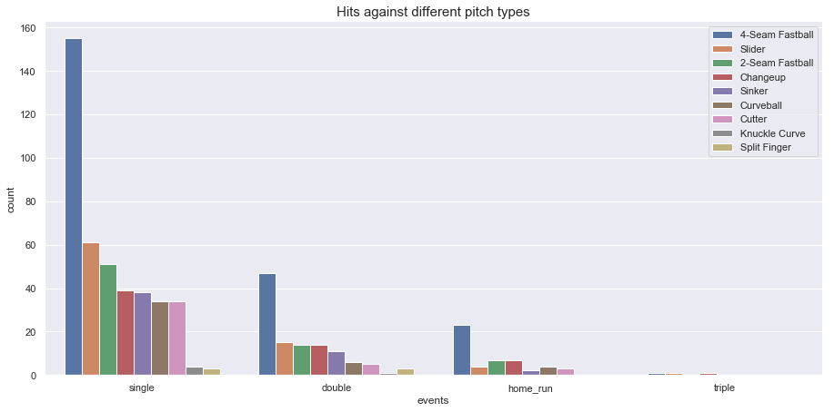

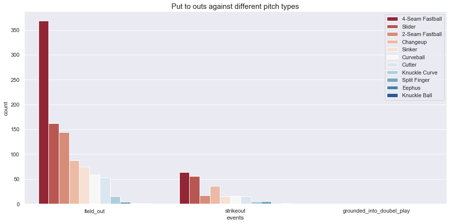

```python
import matplotlib.pyplot as plt
import seaborn as sns

sns.set(style="darkgrid")
#ax = sns.countplot(x="events", hue="pitch_name", data=posey_hits)
g = sns.catplot(x="events", hue="pitch_name",
                hue_order = ['4-Seam Fastball', 'Slider', '2-Seam Fastball', 'Changeup', 'Sinker', 'Curveball', 'Cutter', 'Knuckle Curve', 'Split Finger'],
                order=["single","double","home_run","triple"],
                data=posey_hits, kind="count",
                height=4, aspect=20, legend_out=False)

plt.title("Hits against different pitch types", fontsize=15)

g.fig.set_size_inches(12,7)
plt.legend(loc='upper right')

g2 = sns.catplot(x="events", hue="pitch_name",
                 order=["field_out","strikeout","grounded_into_doubel_play"],
                 hue_order = ['4-Seam Fastball', 'Slider', '2-Seam Fastball', 'Changeup', 'Sinker', 'Curveball', 'Cutter', 'Knuckle Curve', 'Split Finger', 'Eephus', 'Knuckle Ball'],
                 data=posey_outs, kind="count",
                 palette= "RdBu",
                 height=4, aspect=20, legend_out=False)

g2.fig.set_size_inches(12,7)
plt.legend(loc='upper right')
plt.title("Put to outs against different pitch types", fontsize=15)

plt.show()
```

```python
singleType = list(posey_hits[posey_hits.events=="single"].pitch_name.value_counts().values)
singleLabel = list(posey_hits[posey_hits.events=="single"].pitch_name.value_counts().index)


doubleType = list(posey_hits[posey_hits.events=="double"].pitch_name.value_counts().values)
doubleLabel = list(posey_hits[posey_hits.events=="double"].pitch_name.value_counts().index)


tripleType = list(posey_hits[posey_hits.events=="triple"].pitch_name.value_counts().values)
tripleLabel = list(posey_hits[posey_hits.events=="triple"].pitch_name.value_counts().index)


homerType = list(posey_hits[posey_hits.events=="home_run"].pitch_name.value_counts().values)
homerLabel = list(posey_hits[posey_hits.events=="home_run"].pitch_name.value_counts().index)


fieldoutType = list(posey_outs[posey_outs.events=="field_out"].pitch_name.value_counts().values)
fieldoutLabel = list(posey_outs[posey_outs.events=="field_out"].pitch_name.value_counts().index)


KType = list(posey_outs[posey_outs.events=="strikeout"].pitch_name.value_counts().values)
KLabel = list(posey_outs[posey_outs.events=="strikeout"].pitch_name.value_counts().index)


doubleplayType = list(posey_outs[posey_outs.events=="grounded_into_double_play"].pitch_name.value_counts().values)
doubleplayLabel = list(posey_outs[posey_outs.events=="grounded_into_double_play"].pitch_name.value_counts().index)
```

## Hits on different pitch types percentage

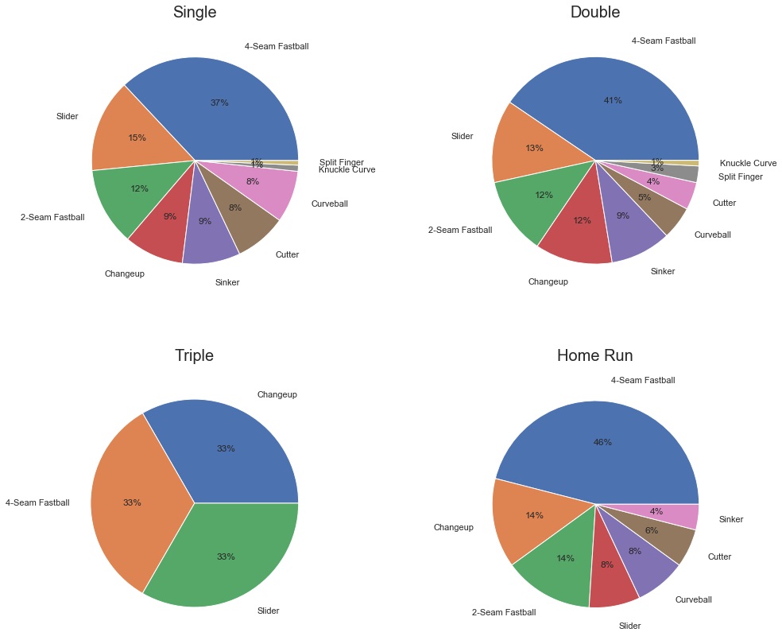

```python
fig = plt.gcf()
ax1 = plt.subplot2grid((2, 2), (0, 0))
ax2 = plt.subplot2grid((2, 2), (0, 1))
ax3 = plt.subplot2grid((2, 2), (1, 0))
ax4 = plt.subplot2grid((2, 2), (1, 1))

ax1.pie(singleType, labels=singleLabel, autopct='%.0f%%', labeldistance= 1.2)
ax1.set_position([0,1, 0.4, 0.4])
ax1.axis('equal')
ax1.set_title('Single',fontsize = 20, y = 1.1)

ax2.pie(doubleType, labels=doubleLabel, autopct='%.0f%%', labeldistance= 1.2)
ax2.set_position([.7,1, 0.4, 0.4])
ax2.axis('equal')
ax2.set_title('Double',fontsize = 20, y = 1.1)

ax3.pie(tripleType, labels=tripleLabel, autopct='%.0f%%', labeldistance= 1.2)
ax3.set_position([0,0.4, 0.4, 0.4])
ax3.axis('equal')
ax3.set_title('Triple',fontsize = 20, y = 1.1)

ax4.pie(homerType, labels=homerLabel, autopct='%.0f%%', labeldistance= 1.2)
ax4.set_position([0.7,0.4, 0.4, 0.4])
ax4.axis('equal')
ax4.set_title('Home Run',fontsize = 20, y = 1.1)

fig.set_size_inches(10,10)

plt.show()
```

## Put to out on different pitch types percentage

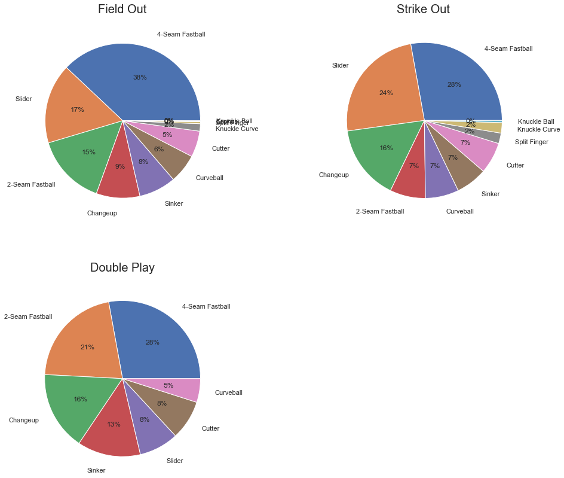

```python
fig = plt.gcf()
ax1 = plt.subplot2grid((2, 2), (0, 0))
ax2 = plt.subplot2grid((2, 2), (0, 1))
ax3 = plt.subplot2grid((2, 2), (1, 0))

ax1.pie(fieldoutType, labels=fieldoutLabel, autopct='%.0f%%', labeldistance= 1.2)
ax1.set_position([0,1, 0.4, 0.4])
ax1.axis('equal')
ax1.set_title('Field Out',fontsize = 20, y = 1.1)

ax2.pie(KType, labels=KLabel, autopct='%.0f%%', labeldistance= 1.2)
ax2.set_position([.7,1, 0.4, 0.4])
ax2.axis('equal')
ax2.set_title('Strike Out',fontsize = 20, y = 1.1)

ax3.pie(doubleplayType, labels=doubleplayLabel, autopct='%.0f%%', labeldistance= 1.2)
ax3.set_position([0,0.4, 0.4, 0.4])
ax3.axis('equal')
ax3.set_title('Double Play',fontsize = 20, y = 1.1)

fig.set_size_inches(10,10)

plt.show()
```

## Launch Speed vs. Launch Angle

[Launch angle](http://m.mlb.com/glossary/statcast/launch-angle): The vertical angle at which the ball leaves a player's bat

[Exit velocity](http://m.mlb.com/glossary/statcast/exit-velocity): The immediate speed of the baseball as it comes off the bat

This new data has changed the way teams value both hitters and pitchers. Why? As per the [Washington Post](https://www.washingtonpost.com/graphics/sports/mlb-launch-angles-story/?utm_term=.8d088d31f098):

> Balls hit with a high launch angle are more likely to result in a hit. Hit fast enough and at the right angle, they become home runs.

The first row of plots are the scatter plots of the launch speed vs. launch angle which are breaks down into 4 types of hits. The second row of plots are the density where the data points located. Posey's home runs generally came with a sweet spot of 25 - 45 launch angle and a launch speed at around 100 mph.

Other types of hits also came with a high density of launch speed around 100 mph, meaning a perfect contact and hard swing at the coming balls. Realize that even with an identical launch angel and speed may still result in total different outcomes, as can be seen from the double and home runs plots. The ball parks and the blowing wind direction may be the the main influence here.

The third rows of plots breaks down the density of launch speed vs. launch angle by seasons, 2015 to 2018. The difference between these seasons are tiny, indicating that Posey hits the ball just as hard in each season without power shading or changing the swinging launch angle. In general, to produce hits, either raise the launch angle or accelerate the swinging speed. They have a negative correlation.

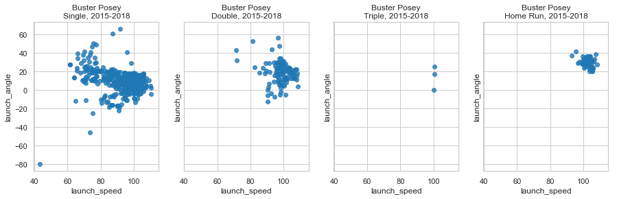

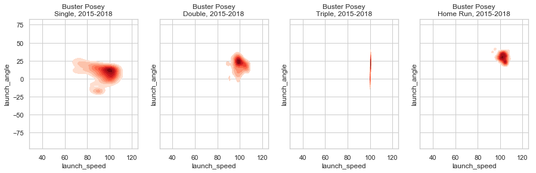

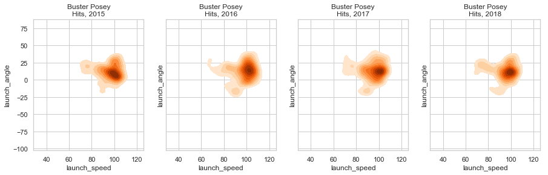

```python
# Create a figure with 4 scatter plots of launch speed vs. launch angle, 1 for each hits event: Single, Double, Triple, Home Run
sns.set(style="whitegrid")
fig1, axs1 = plt.subplots(ncols=4, sharex=True, sharey=True)
sns.regplot(x='launch_speed', y='launch_angle', fit_reg=False, color='tab:blue', data=posey_hits[posey_hits.events=="single"], ax=axs1[0]).set_title('Buster Posey\nSingle, 2015-2018')
sns.regplot(x='launch_speed', y='launch_angle', fit_reg=False, color='tab:blue', data=posey_hits[posey_hits.events=="double"], ax=axs1[1]).set_title('Buster Posey\nDouble, 2015-2018')
sns.regplot(x='launch_speed', y='launch_angle', fit_reg=False, color='tab:blue', data=posey_hits[posey_hits.events=="triple"], ax=axs1[2]).set_title('Buster Posey\nTriple, 2015-2018')
sns.regplot(x='launch_speed', y='launch_angle', fit_reg=False, color='tab:blue', data=posey_hits[posey_hits.events=="home_run"], ax=axs1[3]).set_title('Buster Posey\nHome Run, 2015-2018')
fig1.set_size_inches(15,4)

# Create a figure with 4 KDE plots of launch speed vs. launch angle, 1 for each hits event: Single, Double, Triple, Home Run
fig2, axs2 = plt.subplots(ncols=4, sharex=True, sharey=True)
sns.kdeplot(posey_hits[posey_hits.events=="single"]['launch_speed'], posey_hits[posey_hits.events=="single"]['launch_angle'], cmap="Reds", shade=True, shade_lowest=False, ax=axs2[0]).set_title('Buster Posey\nSingle, 2015-2018')
sns.kdeplot(posey_hits[posey_hits.events=="double"]['launch_speed'], posey_hits[posey_hits.events=="double"]['launch_angle'], cmap="Reds", shade=True, shade_lowest=False, ax=axs2[1]).set_title('Buster Posey\nDouble, 2015-2018')
sns.kdeplot(posey_hits[posey_hits.events=="triple"]['launch_speed'], posey_hits[posey_hits.events=="triple"]['launch_angle'], cmap="Reds", shade=True, shade_lowest=False, ax=axs2[2]).set_title('Buster Posey\nTriple, 2015-2018')
sns.kdeplot(posey_hits[posey_hits.events=="home_run"]['launch_speed'], posey_hits[posey_hits.events=="home_run"]['launch_angle'], cmap="Reds", shade=True, shade_lowest=False, ax=axs2[3]).set_title('Buster Posey\nHome Run, 2015-2018')
fig2.set_size_inches(15,4)

fig3, axs3 = plt.subplots(ncols=4, sharex=True, sharey=True)
sns.kdeplot(posey_hits[posey_hits.game_year==2015]['launch_speed'], posey_hits[posey_hits.game_year==2015]['launch_angle'], cmap='Oranges', shade=True, shade_lowest=False, ax=axs3[0]).set_title('Buster Posey\nHits, 2015')
sns.kdeplot(posey_hits[posey_hits.game_year==2016]['launch_speed'], posey_hits[posey_hits.game_year==2016]['launch_angle'], cmap='Oranges', shade=True, shade_lowest=False, ax=axs3[1]).set_title('Buster Posey\nHits, 2016')
sns.kdeplot(posey_hits[posey_hits.game_year==2017]['launch_speed'], posey_hits[posey_hits.game_year==2017]['launch_angle'], cmap='Oranges', shade=True, shade_lowest=False, ax=axs3[2]).set_title('Buster Posey\nHits, 2017')
sns.kdeplot(posey_hits[posey_hits.game_year==2018]['launch_speed'], posey_hits[posey_hits.game_year==2018]['launch_angle'], cmap='Oranges', shade=True, shade_lowest=False, ax=axs3[3]).set_title('Buster Posey\nHits, 2018')
fig3.set_size_inches(15,4)
```

## Faced pitching velocity ( Effective Speed at Batters' viewpoint )

The faced pitching velocity is measured in miles per hour, using effective speed, it's easy to measure the speed of a given pitch, but to a batter's eye, a pitch might look much faster or slower than it actually is.

The data shows that the difference of average velocity in each type is tiny, generally at around 90 mph, compared to the "put to outs" data, he has equal advantage and disadvantage facing different speed of balls, pitch location may a critical factor. Posey only generates 3 triples among the seasons, so the triple data size is too small to be significant.

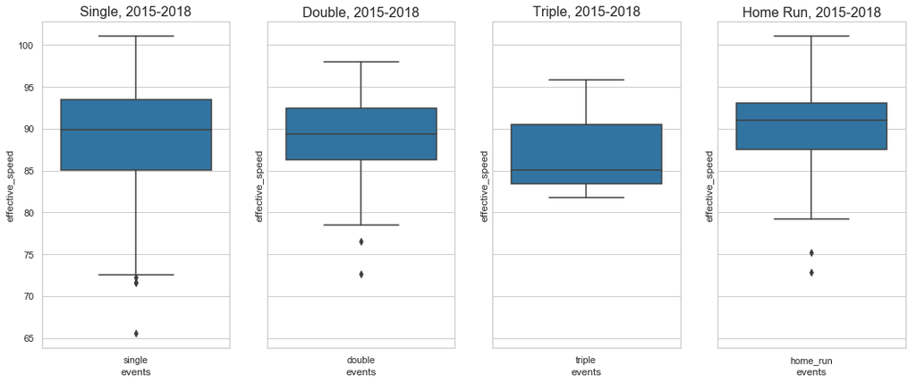

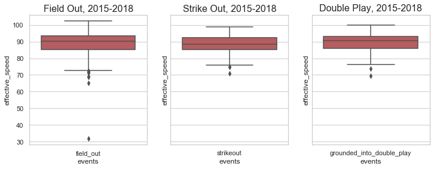

```python
import seaborn as sns
import matplotlib.pyplot as plt
# Create a boxplot that describes the pitch velocity of each player's home runs

fig1, axs1 = plt.subplots(ncols=4, sharey=True)

sns.boxplot(x = posey_hits[posey_hits.events=="single"]['events'], y = posey_hits[posey_hits.events=="single"]['effective_speed'], data = posey_hits, color = 'tab:blue', ax=axs1[0]).set_title('Single, 2015-2018', fontsize = 16)
sns.boxplot(x = posey_hits[posey_hits.events=="double"]['events'], y = posey_hits[posey_hits.events=="double"]['effective_speed'], data = posey_hits, color = 'tab:blue', ax=axs1[1]).set_title('Double, 2015-2018', fontsize = 16)
sns.boxplot(x = posey_hits[posey_hits.events=="triple"]['events'], y = posey_hits[posey_hits.events=="triple"]['effective_speed'], data = posey_hits, color = 'tab:blue', ax=axs1[2]).set_title('Triple, 2015-2018', fontsize = 16)
sns.boxplot(x = posey_hits[posey_hits.events=="home_run"]['events'], y = posey_hits[posey_hits.events=="home_run"]['effective_speed'], data = posey_hits, color = 'tab:blue', ax=axs1[3]).set_title('Home Run, 2015-2018', fontsize = 16)

fig1.set_size_inches(18,7)

fig2, axs2 = plt.subplots(ncols=3, sharey=True)

sns.boxplot(x = posey_outs[posey_outs.events=="field_out"]['events'], y = posey_outs[posey_outs.events=="field_out"]['effective_speed'], data = posey_outs, color = 'r', ax=axs2[0]).set_title('Field Out, 2015-2018', fontsize = 16)
sns.boxplot(x = posey_outs[posey_outs.events=="strikeout"]['events'], y = posey_outs[posey_outs.events=="strikeout"]['effective_speed'], data = posey_outs, color = 'r', ax=axs2[1]).set_title('Strike Out, 2015-2018', fontsize = 16)
sns.boxplot(x = posey_outs[posey_outs.events=="grounded_into_double_play"]['events'], y = posey_outs[posey_outs.events=="grounded_into_double_play"]['effective_speed'], data = posey_outs, color = 'r', ax=axs2[2]).set_title('Double Play, 2015-2018', fontsize = 16)

fig2.set_size_inches(12,4)
```

```python
def assign_x_coord(row):
    """
    Assigns an x-coordinate to Statcast's strike zone numbers. Zones 11, 12, 13,
    and 14 are ignored for plotting simplicity.
    """
    # Left third of strike zone
    if row.zone in [1, 4, 7]:
        return 1
    # Middle third of strike zone
    if row.zone in [2, 5, 8]:
        return 2
    # Right third of strike zone
    if row.zone in [3, 6, 9]:
        return 3

def assign_y_coord(row):
    """
    Assigns a y-coordinate to Statcast's strike zone numbers. Zones 11, 12, 13,
    and 14 are ignored for plotting simplicity.
    """
    # Upper third of strike zone
    if row.zone in [1, 2, 3]:
        return 3
    # Middle third of strike zone
    if row.zone in [4, 5, 6]:
        return 2
    # Lower third of strike zone
    if row.zone in [7, 8, 9]:
        return 1
```

## Hits on pitches in strike zone & Outs on pitches in strike zone

Statcast *does* track pitch movement and type but let's move on to something else: **pitch location**. Statcast tracks the zone the pitch is in when it crosses the plate. The zone numbering looks like this (from the catcher's point of view):

[figure not shown]

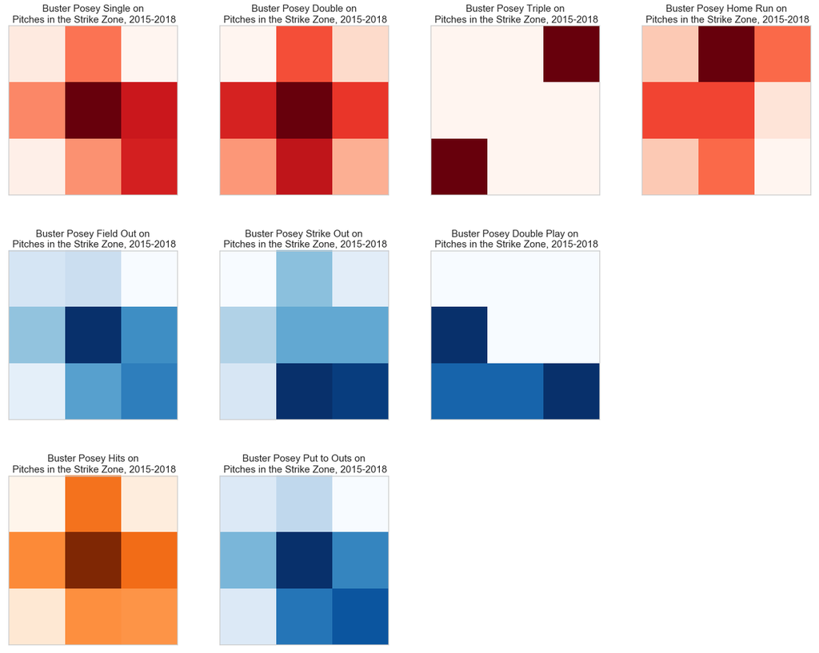

```python
# Zones 11, 12, 13, and 14 are to be ignored for plotting simplicity
posey_hits_zone = posey_hits.copy().loc[posey_hits.zone <= 9]
posey_outs_zone = posey_outs.copy().loc[posey_outs.zone <= 9]

# Assign Cartesian coordinates to pitches in the strike zone for Judge home runs

posey_hits_zone['zone_x'] = posey_hits_zone.apply(assign_x_coord,axis=1)
posey_hits_zone['zone_y'] = posey_hits_zone.apply(assign_y_coord,axis=1)

posey_outs_zone['zone_x'] = posey_outs_zone.apply(assign_x_coord,axis=1)
posey_outs_zone['zone_y'] = posey_outs_zone.apply(assign_y_coord,axis=1)

fig = plt.gcf()

ax1 = plt.subplot2grid((3, 4), (0, 0))
ax2 = plt.subplot2grid((3, 4), (0, 1))
ax3 = plt.subplot2grid((3, 4), (0, 2))
ax4 = plt.subplot2grid((3, 4), (0, 3))
ax5 = plt.subplot2grid((3, 4), (1, 0))
ax6 = plt.subplot2grid((3, 4), (1, 1))
ax7 = plt.subplot2grid((3, 4), (1, 2))
ax8 = plt.subplot2grid((3, 4), (2, 1))
ax9 = plt.subplot2grid((3, 4), (2, 2))


ax1.hist2d(posey_hits_zone[posey_hits_zone.events=="single"]['zone_x'], posey_hits_zone[posey_hits_zone.events=="single"]['zone_y'], bins = 3, cmap='Reds')
ax1.set_title('Buster Posey Single on\n Pitches in the Strike Zone, 2015-2018', fontsize = 15)
ax1.get_xaxis().set_visible(False)
ax1.get_yaxis().set_visible(False)
ax1.set_position([0,0.5, 0.2, 0.45])


ax2.hist2d(posey_hits_zone[posey_hits_zone.events=="double"]['zone_x'], posey_hits_zone[posey_hits_zone.events=="double"]['zone_y'], bins = 3, cmap='Reds')
ax2.set_title('Buster Posey Double on\n Pitches in the Strike Zone, 2015-2018', fontsize = 15)
ax2.get_xaxis().set_visible(False)
ax2.get_yaxis().set_visible(False)
ax2.set_position([.25,0.5, 0.2, 0.45])

ax3.hist2d(posey_hits_zone[posey_hits_zone.events=="triple"]['zone_x'], posey_hits_zone[posey_hits_zone.events=="triple"]['zone_y'], bins = 3, cmap='Reds')
ax3.set_title('Buster Posey Triple on\n Pitches in the Strike Zone, 2015-2018', fontsize = 15)
ax3.get_xaxis().set_visible(False)
ax3.get_yaxis().set_visible(False)
ax3.set_position([.5,0.5, 0.2, 0.45])


ax4.hist2d(posey_hits_zone[posey_hits_zone.events=="home_run"]['zone_x'], posey_hits_zone[posey_hits_zone.events=="home_run"]['zone_y'], bins = 3, cmap='Reds')
ax4.set_title('Buster Posey Home Run on\n Pitches in the Strike Zone, 2015-2018', fontsize = 15)
ax4.get_xaxis().set_visible(False)
ax4.get_yaxis().set_visible(False)
ax4.set_position([0.75,0.5, 0.2, 0.45])


ax5.hist2d(posey_outs_zone[posey_outs_zone.events=="field_out"]['zone_x'], posey_outs_zone[posey_outs_zone.events=="field_out"]['zone_y'], bins = 3, cmap='Blues')
ax5.set_title('Buster Posey Field Out on\n Pitches in the Strike Zone, 2015-2018', fontsize = 15)
ax5.get_xaxis().set_visible(False)
ax5.get_yaxis().set_visible(False)
ax5.set_position([0,-0.1, 0.2, 0.45])

ax6.hist2d(posey_outs_zone[posey_outs_zone.events=="strikeout"]['zone_x'], posey_outs_zone[posey_outs_zone.events=="strikeout"]['zone_y'], bins = 3, cmap='Blues')
ax6.set_title('Buster Posey Strike Out on\n Pitches in the Strike Zone, 2015-2018', fontsize = 15)
ax6.get_xaxis().set_visible(False)
ax6.get_yaxis().set_visible(False)
ax6.set_position([.25,-0.1, 0.2, 0.45])

ax7.hist2d(posey_outs_zone[posey_outs_zone.events=="grounded_into_double_play"]['zone_x'], posey_outs_zone[posey_outs_zone.events=="grounded_into_double_play"]['zone_y'], bins = 3, cmap='Blues')
ax7.set_title('Buster Posey Double Play on\n Pitches in the Strike Zone, 2015-2018', fontsize = 15)
ax7.get_xaxis().set_visible(False)
ax7.get_yaxis().set_visible(False)
ax7.set_position([.5,-0.1, 0.2, 0.45])

ax8.hist2d(posey_hits_zone['zone_x'], posey_hits_zone['zone_y'], bins = 3, cmap='Oranges')
ax8.set_title('Buster Posey Hits on\n Pitches in the Strike Zone, 2015-2018', fontsize = 15)
ax8.get_xaxis().set_visible(False)
ax8.get_yaxis().set_visible(False)
ax8.set_position([0,-0.7, 0.2, 0.45])

ax9.hist2d(posey_outs_zone['zone_x'], posey_outs_zone['zone_y'], bins = 3, cmap='Blues')
ax9.set_title('Buster Posey Put to Outs on\n Pitches in the Strike Zone, 2015-2018', fontsize = 15)
ax9.get_xaxis().set_visible(False)
ax9.get_yaxis().set_visible(False)
ax9.set_position([0.25,-0.7, 0.2, 0.45])

fig.set_size_inches(18,8)
```

## Conclusion

First row of plots are the hits types on pitches in strike zone, second row are those events not getting on the bases, the third one is the summary for both events, either get on base or out.

We can see that, like all other hitters, Posey hits much more in the middle of the strike zone. For singles, the second high contact would be the outter corner of the strike zone. Home runs produced more frequently from a middle up corner of the strike zone. Doubles come from all 4 sides, but tend to be at the inner strike zone. The result of been put to outs may require the consideration of those pitches outside the strike zone, but outter strike zone tend to be his weakness.

To sum up, Posey hits pretty well in the middle and outter-bottom side of the strike zone, but also got outs frequently at the same locations. Suggested next that spin rate and the lefty or righty faced may influence the results.

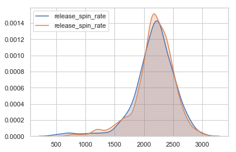

```python
sns.kdeplot(posey_hits[(posey_hits.zone==5)|(posey_hits.zone==6)|(posey_hits.zone==8)|(posey_hits.zone==9)].release_spin_rate.dropna(), shade=True)
sns.kdeplot(posey_outs[(posey_outs.zone==5)|(posey_outs.zone==6)|(posey_outs.zone==8)|(posey_outs.zone==9)].release_spin_rate.dropna(), shade=True)
```

Spin rates with the 2 events are almost the same, the blue histogram refers to the event of hits, the orange one refers to not getting on the bases. The below statistics summary also shows that 2 events have nearly the same average spin rates in the outter lower side of the strike zone, defined by zone 5, 6, 8, 9. Thus the causation of the events of hits or got outs may boil down to the pitcher types, meaning whether he's lefty or righty, pitching time, released points and so forth. Personal condition in the game is also a critical factor to the results.

```python
print("\n")
print("Hits against pitching spin rate")
print("\n")
print(posey_hits[(posey_hits.zone==5)|(posey_hits.zone==6)|(posey_hits.zone==8)|(posey_hits.zone==9)].release_spin_rate.describe())
print("\n")
print("Outs against pitching spin rate")
print("\n")
print(posey_outs[(posey_outs.zone==5)|(posey_outs.zone==6)|(posey_outs.zone==8)|(posey_outs.zone==9)].release_spin_rate.describe())
```

```
Hits against pitching spin rate


count     238.000000
mean     2174.689076
std       359.520197
min       503.000000
25%      2015.500000
50%      2210.000000
75%      2393.500000
max      2997.000000
Name: release_spin_rate, dtype: float64


Outs against pitching spin rate


count     497.000000
mean     2184.458753
std       332.166014
min       769.000000
25%      2048.000000
50%      2204.000000
75%      2387.000000
max      3012.000000
Name: release_spin_rate, dtype: float64
```